# PyPSA-LAEP · buildings and the local energy system

### The most developed residential reference case · Westborough complete-zone study

What changes when retrofit, heating choices, flexibility and the electricity network are considered together? This is the central question behind PyPSA-LAEP.

The reference case contains **2,974 dwellings across 33 electrical zones**, with a 2035 national-system boundary. It is selected here for its saved investment results, spatial outputs and targeted hourly replay—not because it is a validated town-wide plan. Results were generated on **6 September 2026**, using the earlier EnerMap handoff. The latest EnerMap release is presented separately in Notebook 01.

|  | Saved economic solution |
| --- | --- |
| Dwellings | 2974.000 |
| Electrical zones | 33.000 |
| Annualised system cost (£m/year) | 3.407 |
| Space-heat reduction (%) | 28.558 |
| Operational emissions (ktCO2/year) | 3.890 |

## 1 · The whole-system idea, within an explicit boundary

Fabric changes demand; heating changes the carrier used to meet it; hourly operation changes network loading. Solving these decisions together captures trade-offs that independent technology calculations miss. Here “whole system” means the **modelled residential, electricity and heating boundary**—not all sectors of Guildford yet.

| Decision or boundary | Representation in the saved model |
| --- | --- |
| Retrofit and heating choice | Continuous cluster shares over eligible package–technology options |
| Electricity and heat balances | PyPSA buses, loads and conversion links |
| Heat pumps and boilers | Links with efficiencies/COPs and capacity tied to adopted stock |
| Flexibility | Fabric and cylinder storage representations |
| Network | Zone transfer limits, transformer losses, optional reinforcement |
| National context | PyPSA-GB/FES24 HT 2035 prices/carbon mapped from solved winter/summer weeks |

The boundary is one-way: this study does not iteratively change the national system. There is no EV or completed non-residential demand here, and DH is disabled in this case.

## 2 · What did the model choose?

Fabric measures are selected widely, but low heat demand does not automatically imply universal electrification. Existing boilers have sunk capital in this setup; fuel, electricity and carbon assumptions influence the balance. The chart reports dwelling **equivalents**, not identified household installations.

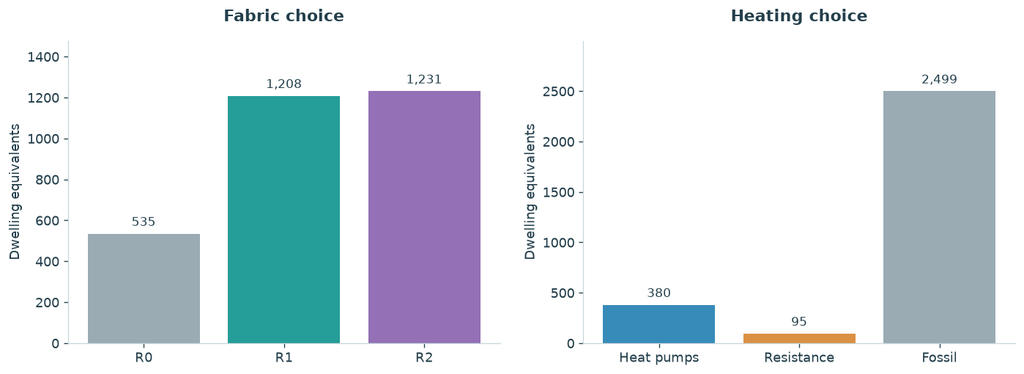

```
Retrofit uptake: 82.0% of dwellings.
Space-heat reduction: 28.6%; clean heat: 23.0% of useful heat (different denominator).
```

## 3 · The pattern is spatial

These are the saved zone-level results. Marker size reflects dwelling count; colour shows the share adopting each measure. Zones cover complete inferred substation groups, so the study extends beyond the named ward boundary. This map is not a DNO-verified connection diagram or a household-level recommendation.

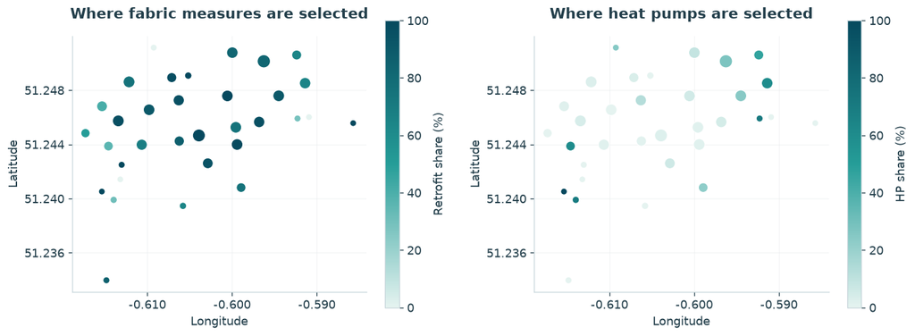

## 4 · Less heat is needed; the network still needs checking

The selected fabric mix reduces useful space heat from about 25.04 to 17.89 GWh/year. That reduction is separate from heating efficiency. The right-hand panel shows peak loading in the **typical-day investment model**, not a full-year duration curve.

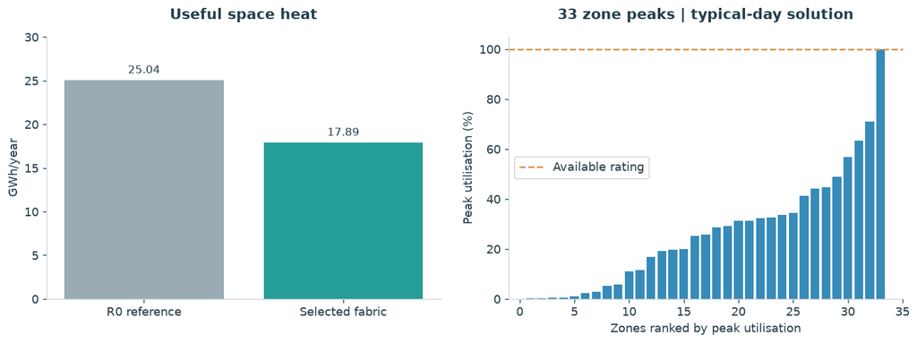

## 5 · An hourly replay, with a limited scope

The saved replay fixes investment decisions and re-optimises operation across a full year for **three of the 33 zones**. It finds no material unmet heat or electricity in that subset. The grid-import change is small, but this does not establish feasibility for every zone. The 221 hours near rating are **summed zone-hours**, not unique hours for the area. Fabric storage also remains a comfort proxy rather than a validated indoor-temperature simulation.

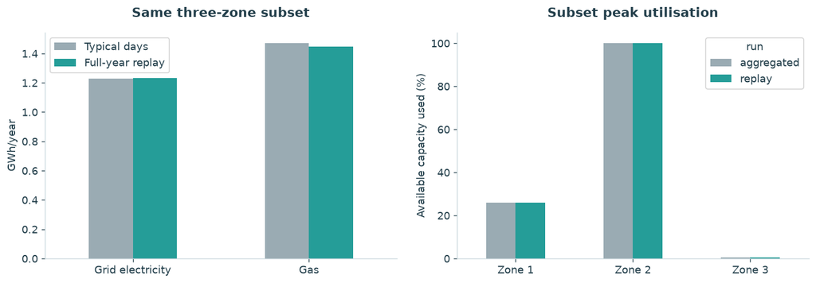

```
Subset import difference: 0.57%
```

| metric | replay | unit |
| --- | --- | --- |
| zones | 3.000e+00 | count |
| unmet_heat_mwh | 9.144e-12 | MWh/yr - must be ~0 |
| unmet_elec_mwh | 0.000e+00 | MWh/yr - must be 0 |
| hours_above_95pct | 2.210e+02 | weighted h/yr, all replayed zones |

## 6 · What sits behind the costs?

The £3.41m/year objective is an **annualised system cost**, including configured carbon valuation—not a household bill, grant budget or an upfront investment total. The saved case adds £60/MWh to its national electricity-price boundary, assumes gas at £26.26/MWh, and uses £317.60/tCO2 carbon value with an £85/t embedded electricity-carbon allowance. It has no minimum clean-heat share or carbon cap.

The tables below expose the original model inputs. **They are not newly verified market quotes.** Price years are mixed and normalisation is disabled; compare scenarios with shared assumptions, and treat absolute costs as preliminary. Existing-boiler capital is sunk. Emitters and retrofit quantities add costs beyond the basic technology curve.

| Heating option | enabled | capex_fixed_gbp_per_dwelling | capex_gbp_per_kw | lifetime | price_year |
| --- | --- | --- | --- | --- | --- |
| gas_boiler_existing | True | 0 | 0 | 15 | 2019 |
| other_fossil_existing | True | 0 | 0 | 15 | 2019 |
| ashp | True | 4663.25 | 287.2 | 15 | 2019 |
| ashp_underfloor | True | 4663.25 | 287.2 | 15 | 2019 |
| gshp | True | 8151.25 | 406.5 | 20 | 2019 |
| resistive | True | 235.8 | 117.4 | 15 | 2019 |
| dh_connection | False | 0 | 0 | 40 | 2022 |

| Fabric measure | value | unit | lifetime | price_year |
| --- | --- | --- | --- | --- |
| cavity_fill | 14 | m2 | 40 | 2021 |
| solid_wall_iwi | 90 | m2 | 36 | 2021 |
| loft_topup | 18 | m2 | 40 | 2021 |
| flat_roof | 95 | m2 | 30 | 2021 |
| glazing_upgrade | 420 | m2 | 30 | 2021 |
| draught_proofing | 300 | dwelling | 15 | 2021 |
| shared_enabling_works | 1500 | building | 40 | 2021 |

```
Discount rate: 0.035 | Price normalisation: False
```

## 7 · A useful counterexample: retrofit under a clean-heat requirement

A separate controlled pair requires 100% clean heat: one holds fabric at R0, the other allows R1/R2. With retrofit, the saved model chooses substantially more resistance heating and fewer heat pumps. **System cost falls while electricity use rises.** This is a technology-choice effect, not evidence that fabric insulation increases heat demand. This pair has not completed the same hourly replay check.

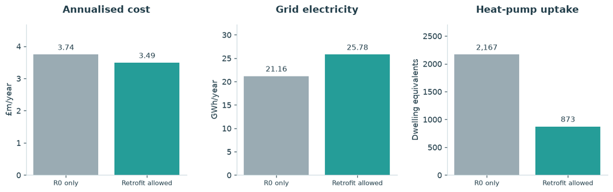

## 8 · Why the wider Guildford result is still screening

The larger saved study combines ten independently solved, ward-labelled groups: 28,662 dwellings and 271 zones. It is useful for seeing spatial differences, but the combined import peaks at about **60.36 MW**, above the assumed 40 MW upstream headroom. The next iteration must enforce that shared limit jointly; calling the existing aggregation a feasible town-wide optimum would be misleading.

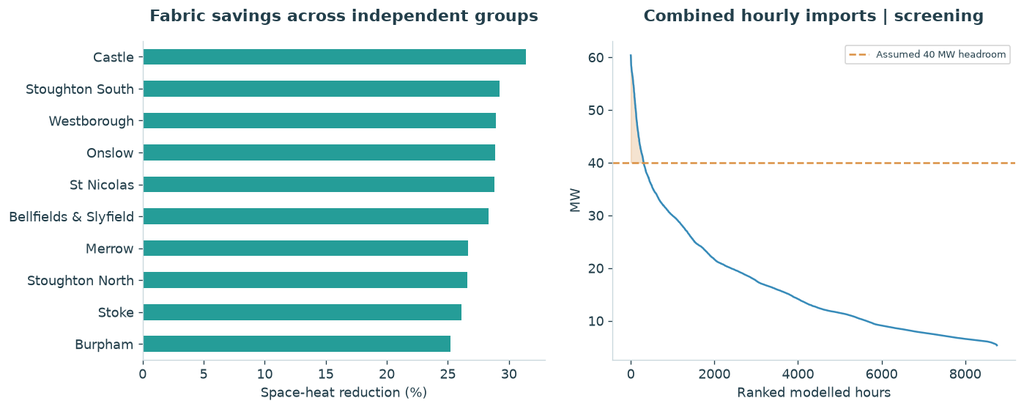

```
Combined peak: 60.36 MW; modelled hours above 40 MW: 307
```

## Where this leaves the framework

The completed work demonstrates integrated residential investment and operation, with spatial and hourly checks. The next milestones are the latest EnerMap rerun, whole-case replay, a joint upstream constraint, cost-year harmonisation and uncertainty tests. EVs, non-residential anchors and multi-period pathways belong to subsequent results—not the completed claims in this notebook.

See scope and units and source provenance.